# Mapping and Spatial Analysis for Hydrologic Data

## Our Turn

```r
# Add fill and border layers to Oregon counties
tm_shape(mult_wide) +
  tm_polygons(c("Median_Income", "Perc_College_Ed")) +
  tm_facets(sync = TRUE, ncol = 2)
```

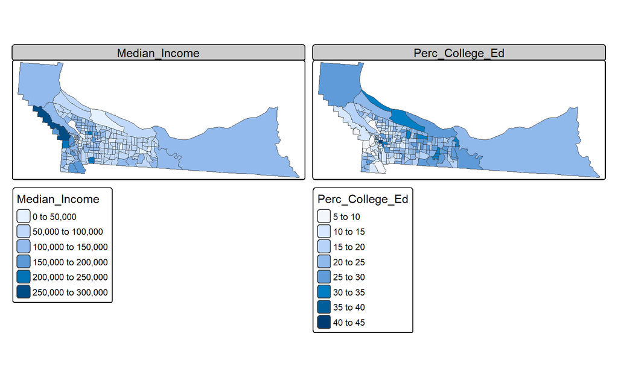

Figure 32: Median income and percent college degree in Multnomah County.

## `tmap`

```r
data(CraterLake)
filepath <- system.file("extdata", "elevation.tif", package = "Rspatialworkshop")
elevation <- rast(filepath)

tm_shape(CraterLake) +
  tm_polygons(lwd = 2) +
  tm_shape(elevation) +
  tm_raster(alpha = 0.7,palette = terrain.colors(12)) +
  tm_layout(legend.position = c("left", "bottom"), legend.width = 1)
```

## `tmap`

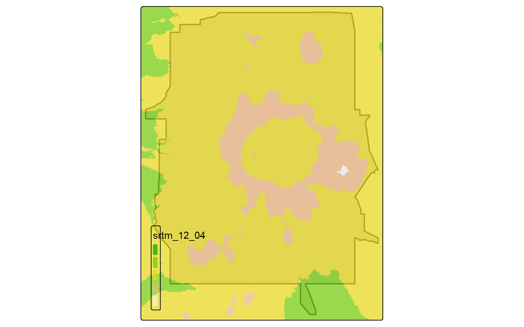

Figure 33: Crater Lake elevation.

# Geoprocessing

## Goals

- Learn about fundamental spatial operations in R using spatial predicates in `sf` for geometric operations
- Explore performing ‘map algebra’ type operations with raster data in R
- Learn how to do extract and zonal operations in R

## Libraries

Recall that `sf` has functions to access three primary underlying geospatial libraries:

1. `GDAL`: For reading and writing data
2. `GEOS`: For geometrical operations
3. `PROJ` for projection conversions and datum transformations

We leverage `sf` and these libraries to perform subsetting, joins, buffering, unions, intersections, clipping, and more

## Simple Features

- `LINESTRING`s are simple if they don’t self-intersect
- `POLYGON`s are simple if their rings are closed, holes are self-contained, and rings don’t repeat their own path

## Predicates

- A predicate asserts whether a property is `TRUE`
- A predicate is unary if it describes the property of a (single) geometry
  - `is`, `is_simple`, `is_valid()`, `is_empty()`, etc.
- A predicate is binary if it describes the property of two geometries
  - `contains()`, `equals()`, `intersects()`, `touches()`, `within()`, etc.

## Measures and Units

Leverage GEOS to answer questions like:

- How long is a line or polygon perimeter?
- What is the area of a polygon?
- What is the distance between two objects?

## Calculating Distances

- Using `st_area()`

```r
counties_area <- sum(st_area(counties))
paste0("The total area of all counties in Oregon is ", round(counties_area), " square meters.")
```

```
[1] "The total area of all counties in Oregon is 250839764883 square meters."
```

- Between stream gages

```r
st_distance(gages_sf[1,], gages_sf[2,])
```

```
Units: [m]
         [,1]
[1,] 58822.95
```

## Your Turn

- Set a projection that uses the proper units
- Use the `units` **R** package to explicitly set units on a vector
- Apply the conversion factor manually

Use one of these approaches to return the same stream gage distance using different units

`04:00`

## Our Turn

```r
# setting projection
gages_ft <- st_transform(gages_sf, 2994)
st_distance(gages_ft[1,], gages_ft[2,])
```

```
Units: [foot]
         [,1]
[1,] 193550.5
```

## Spatial Subsetting

- Use subset notation (`[]`) to take a spatial object and return a new spatial object that contains only the features that relate in space to another spatial object

```r
library(AOI)
filepath <- system.file("extdata/cities.shp", package = "Rspatialworkshop")
or_cities <- read_sf(filepath)
mult_cnty <- aoi_get(state = "OR", county= "Multnomah") |>
  st_transform(st_crs(or_cities))
mult_cities <- or_cities[mult_cnty, , op = st_intersects]
mapview(mult_cnty, alpha.regions=.07, color='black', lwd=2) +
  mapview(mult_cities)
```

## Spatial Subsetting

[figure not shown]

Figure 34: Cities in Multnomah County.

## Your Turn

`04:00`

## Our Turn

```r
close_mult_cities <- or_cities[mult_cnty, , op=st_is_within_distance,dist=50000]
mapview(mult_cnty, alpha.regions=.07, color='black', lwd=2) +
  mapview(close_mult_cities)
```

## Our Turn

[figure not shown]

## Spatial Join

We may want to join together information from one spatial data with another spatial data set

```r
counties <- aoi_get(state='Oregon', county='all') |>
  st_transform(st_crs(or_cities))
cty_cnty <- st_join(or_cities, counties['name'], .predicate = st_intersects)
glimpse(cty_cnty)
```

```
Rows: 898
Columns: 8
$ AREA      <dbl> 0, 0, 0, 0, 0, 0, 0, 0, 0, 0, 0, 0, 0, 0, 0, 0, 0, 0, 0, 0, …
$ PERIMETER <dbl> 0, 0, 0, 0, 0, 0, 0, 0, 0, 0, 0, 0, 0, 0, 0, 0, 0, 0, 0, 0, …
$ CITIES_   <dbl> 1, 2, 3, 4, 5, 6, 7, 8, 9, 10, 11, 12, 13, 14, 15, 16, 17, 1…
$ CITIES_ID <dbl> 1658, 1368, 1366, 1382, 1384, 1380, 1376, 1370, 1378, 1386, …
$ CITY      <chr> "MULINO", "HAMMOND", "FORT STEVENS", "GLIFTON", "BRADWOOD", …
$ FLAG      <int> 0, 0, 0, 0, 0, 0, 1, 2, 0, 0, 0, 0, 0, 0, 2, 2, 0, 0, 0, 0, …
$ geometry  <POINT [foot]> POINT (776899.8 1272019), POINT (439320.8 1638725),…
$ name      <chr> "Clackamas", "Clatsop", "Clatsop", "Clatsop", "Clatsop", "Cl…
```

## Spatial Join

- Left join is the default: Keep all variables from `x` and add variables from `y` that match a key in `x`
- Inner join: A left join but remove rows that don’t have a matching key in `y`

## Buffer and Dissolve

You may want to create buffers around locations

```r
# Filter for metro areas
metros <- or_cities |>
  dplyr::filter(CITY %in% c('PORTLAND','SALEM','EUGENE','CORVALLIS','BEND','MEDFORD'))
# Buffer larger cities
metro_areas <- metros |>
  st_buffer(105600)
```

```r
mapview(metro_areas)
```

## Buffer and Dissolve

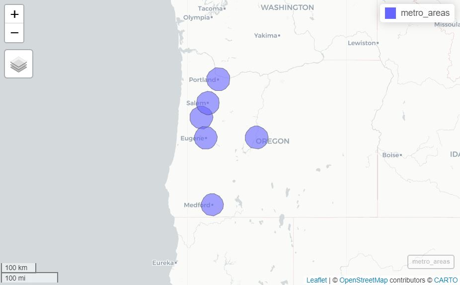

Figure 36: Large Oregon cities with a 20 mile buffer.

## Buffer and Dissolve

Several tidyverse functions to easily dissolve:

```r
counties |>
  group_by(combined_area_code) |>
  summarize(mean_land_area = mean(land_area))
```

```
Simple feature collection with 5 features and 2 fields
Geometry type: GEOMETRY
Dimension:     XY
Bounding box:  xmin: 183987.2 ymin: 88503.92 xmax: 2345098 ymax: 1677526
Projected CRS: Custom
# A tibble: 5 × 3
  combined_area_code mean_land_area                                     geometry
               <int>          <dbl>                            <GEOMETRY [foot]>
1                140    7765492007  POLYGON ((1471754 700225.7, 1472126 679022.…
2                147   25609051307  MULTIPOLYGON (((2256795 111211.3, 2255796 1…
3                366    5726335136. POLYGON ((538081.4 104320.9, 511321.9 10575…
4                440    2672640577. POLYGON ((974023.7 1064655, 973677.6 106334…
5                 NA    7817361077. POLYGON ((345015.5 110785.8, 333429 111425.…
```

## Clipping

```r
plot(st_geometry(metro_areas[2, ]), axes=TRUE)
plot(st_geometry(counties[metro_areas[2,], ]), border = "grey", add = TRUE)
```

## Clipping

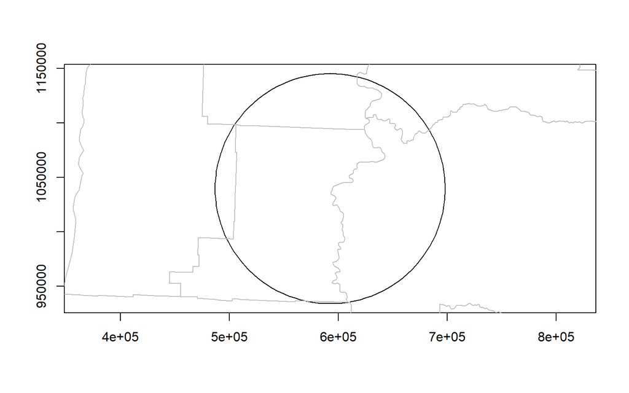

Figure 37: Metro area geometry.

## Clipping

Keep only intersecting geometry

```r
metro_county_area <- st_intersection(metro_areas[2,], counties)
plot(st_geometry(metro_county_area), border = "grey", axes = TRUE)
```

## Clipping

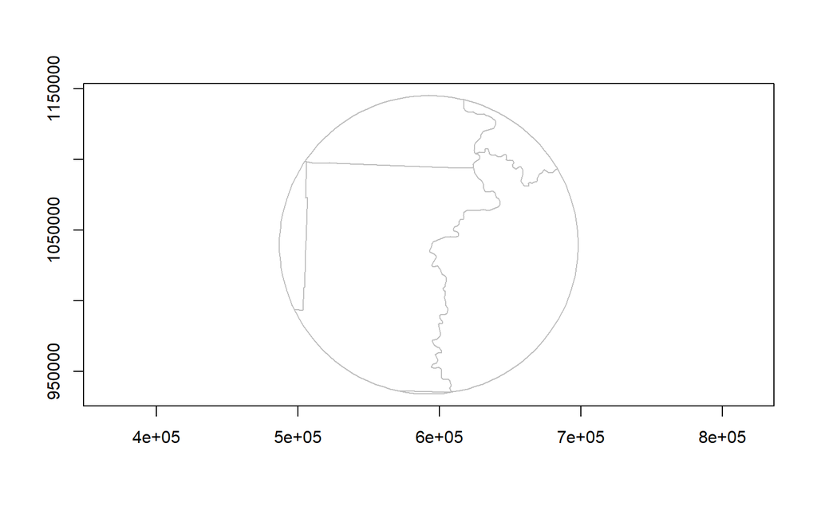

Figure 38: Metro area geometry clipped.

## Centroids and Type Transformations

A centroid is the center of mass on a feature:

```r
sel_counties <- counties |>
  dplyr::filter(name %in% c('Marion','Yamhill','Polk','Benton','Multnomah','Clackamas','Linn','Washington'))
cnt_cent1 <- st_centroid(sel_counties)
```

```r
tm_shape(sel_counties) +
  tm_borders() +
  tm_shape(cnt_cent1) +
  tm_symbols(shape = 1, col = "black", size = 0.5)
```

## Centroids and Type Transformations

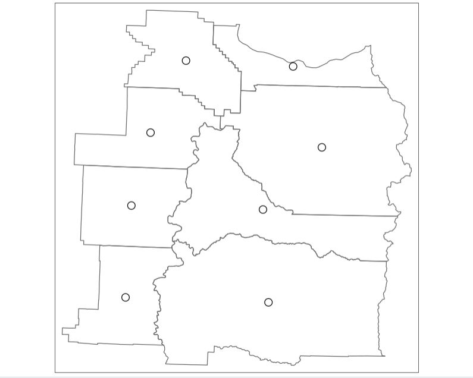

Figure 39: Centroids for Oregon select counties.

## Your Turn

Sometimes the centroid of a geometry does not lie within the geometry’s boundaries. The function `st_point_on_surface()` acts similarly but requires this point is on the surface. In the previous code to visualize the centroids, replace `st_centroid()` with `st_point_on_surface()` and re-visualize.

`03:00`

## Our Turn

```r
cnt_cent2 <- st_point_on_surface(sel_counties)
```

```r
tm_shape(sel_counties) +
  tm_borders() +
  tm_shape(cnt_cent2) +
  tm_symbols(shape = 1, col = "red", size = 0.5)
```

## Our Turn

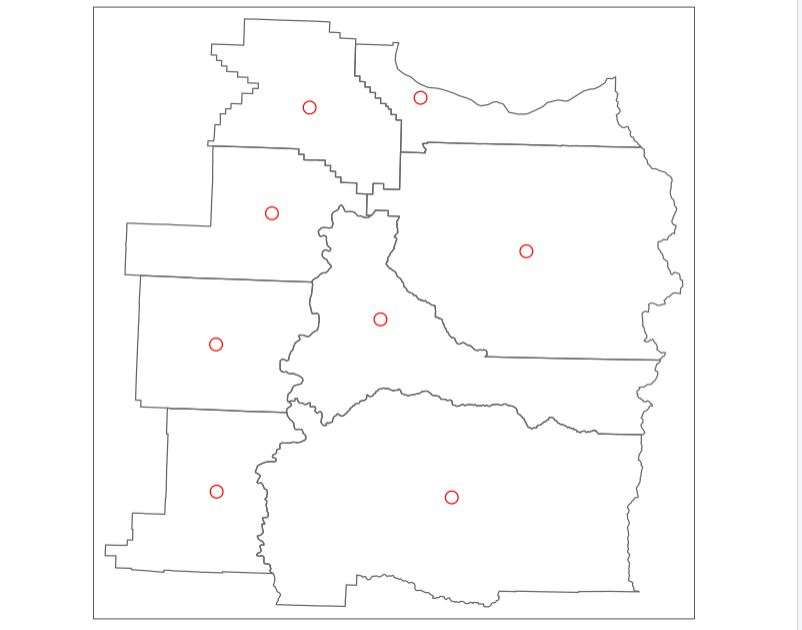

Figure 40: Point on surface for Oregon select counties.

## Simplification

- It can be useful to simplify geometries to save memory and improve efficiency

```r
SouthSantiam <- dataRetrieval::findNLDI(nwis = "14187200", nav = "UT", find = "flowlines", distance_km=10)
SouthSantiam <- SouthSantiam$UT_flowlines |>
  st_transform(st_crs(counties))

Sant_simp <-  st_simplify(SouthSantiam, dTolerance = 500)  # 500 m
p1 <-  tm_shape(SouthSantiam) +
  tm_lines()
p2 <-  tm_shape(Sant_simp) +
  tm_lines()
tmap_arrange(p1, p2, ncol = 2)
```

## Simplification

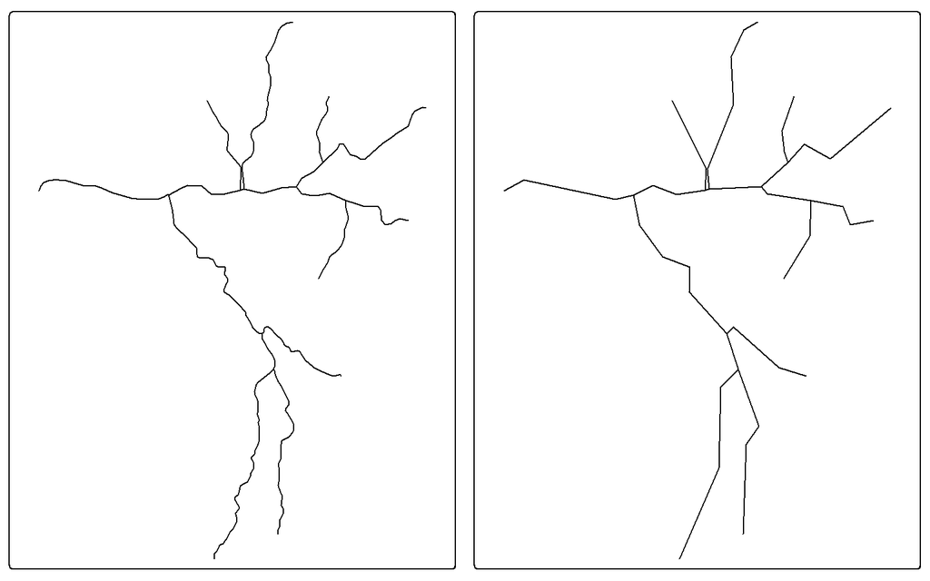

Figure 41: South Santiam geometry and simplified geometry.

## Raster Operations

- The workbook has many examples of geoprocessing using raster data
- Cropping
- Map algebra (local, focal, and global operations)
- Zonal operations

# Advanced Applications

## Goals

- Gain familiarity with using web services for several applications in R
- Learn about using STAC resources in R

## Using Web Services

- Hydrology data with `nhdplusTools` and `dataRetrieval`
- Watershed data with `StreamCatTools`
- Elevation as a service
- OpenDAP and STAC

## Zonal Statistics

- The `zonal` package

PNW Tribal Coding Retreat